# Ps0

## 4. What happens if you map the same variable to multiple aesthetics?

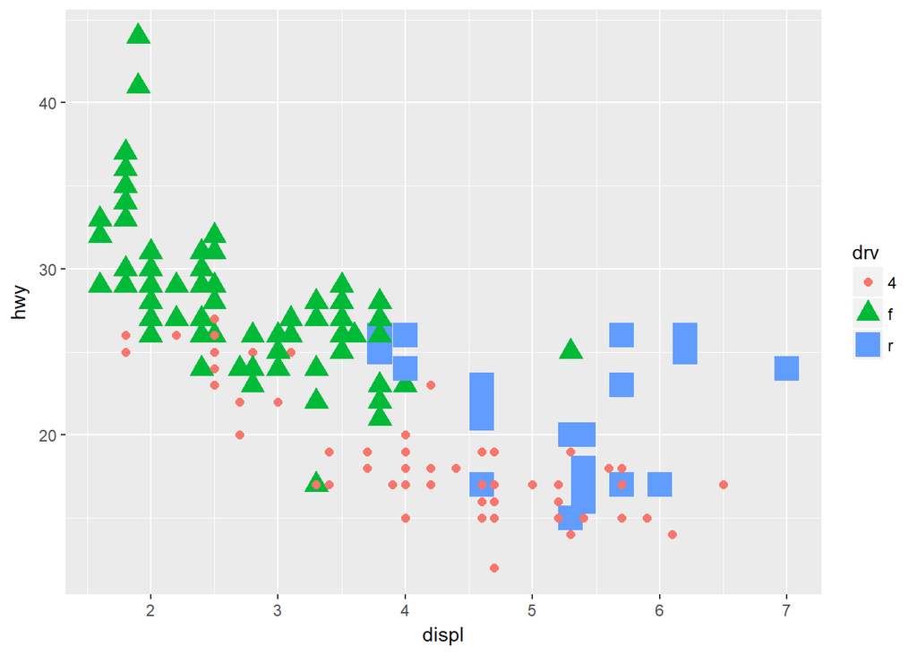

```r
ggplot(data = mpg) +
  geom_point(mapping = aes(x = displ, y = hwy, shape=drv ,size=drv , color=drv))
```

Every category has specific size, color and shape at the same size. For example, “f” will always be a green medium size triangle.

## 5. What does the stroke aesthetic do? What shapes does it work with? (Hint: use ?geom_point or google)

```r
?geom_point
```

The stroke aesthetic modifies the width for shapes that have a border and that you can colour the inside and outside separately. It works in the following way:

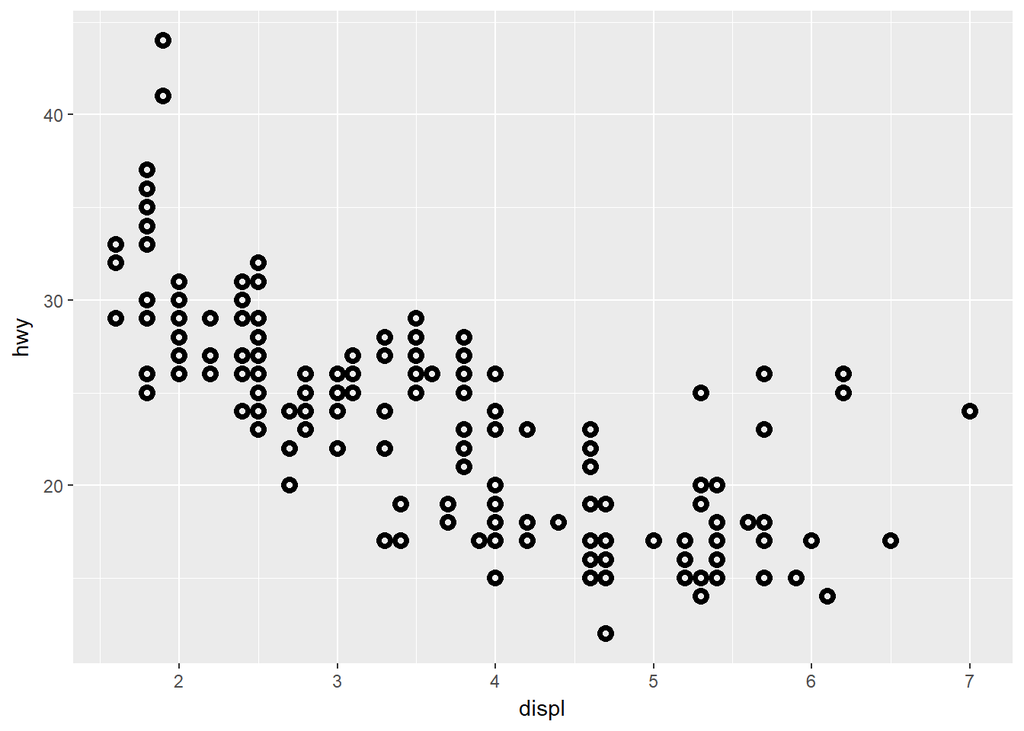

```r
ggplot(data = mpg) +
  geom_point(mapping = aes(x = displ, y = hwy), shape=21, stroke=2 )
```

## 6. What happens if you map an aesthetic to something other than a variable name, like aes(colour =displ < 5)?

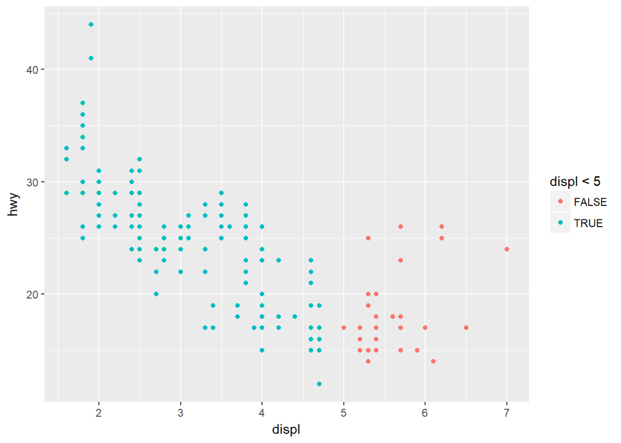

```r
ggplot(data = mpg) +
  geom_point(mapping = aes(x = displ, y = hwy, col=displ<5))
```

R generates a new temporary variable where the points that meet the condition are colored in blue, red otherwise

# 2.3

## 1. What happens if you facet on a continuous variable?

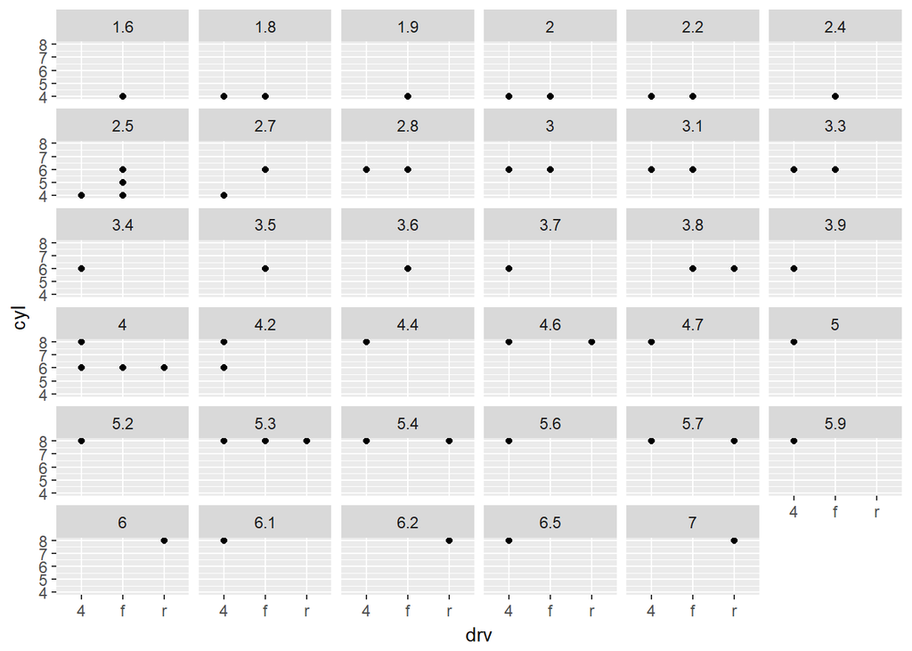

```r
ggplot(data = mpg) +
  geom_point(mapping = aes(x = drv, y = cyl))+
  facet_wrap(~displ)
```

It makes small bins that are scatter plots within the scatter plot.

## 2. What do the empty cells in plot with facet_grid(drv ~ cyl) mean? How do they relate to this plot?

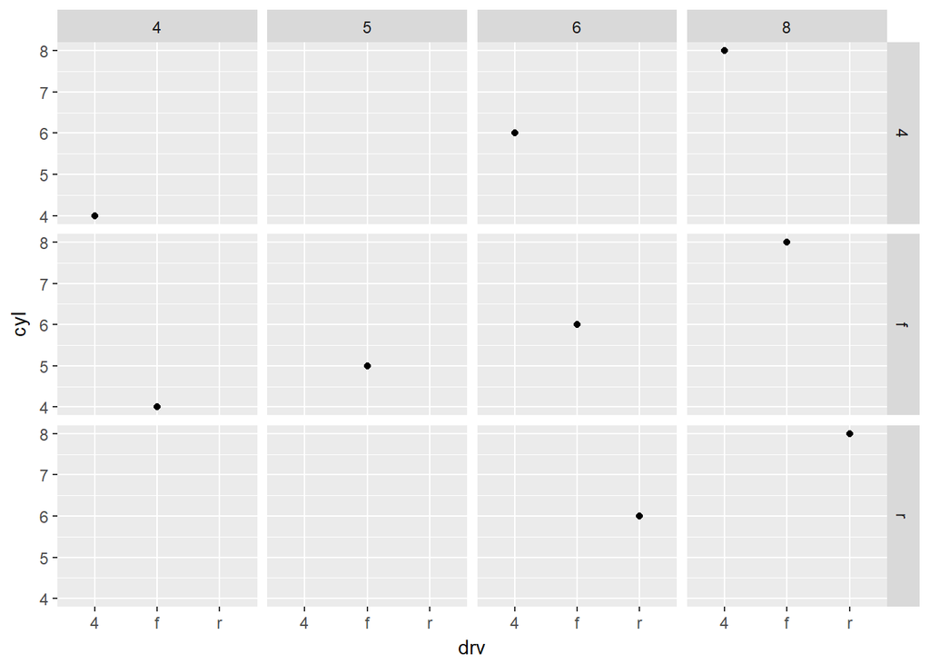

```r
ggplot(data = mpg) +
  geom_point(mapping = aes(x = drv, y = cyl))+
  facet_grid(drv ~ cyl)
```

We have a two dimensional scatterplot. A empty plot will mean there is no observation for that pair of characteristics (drv,cyl)

## 3. What plots does the following code make? What does . do?

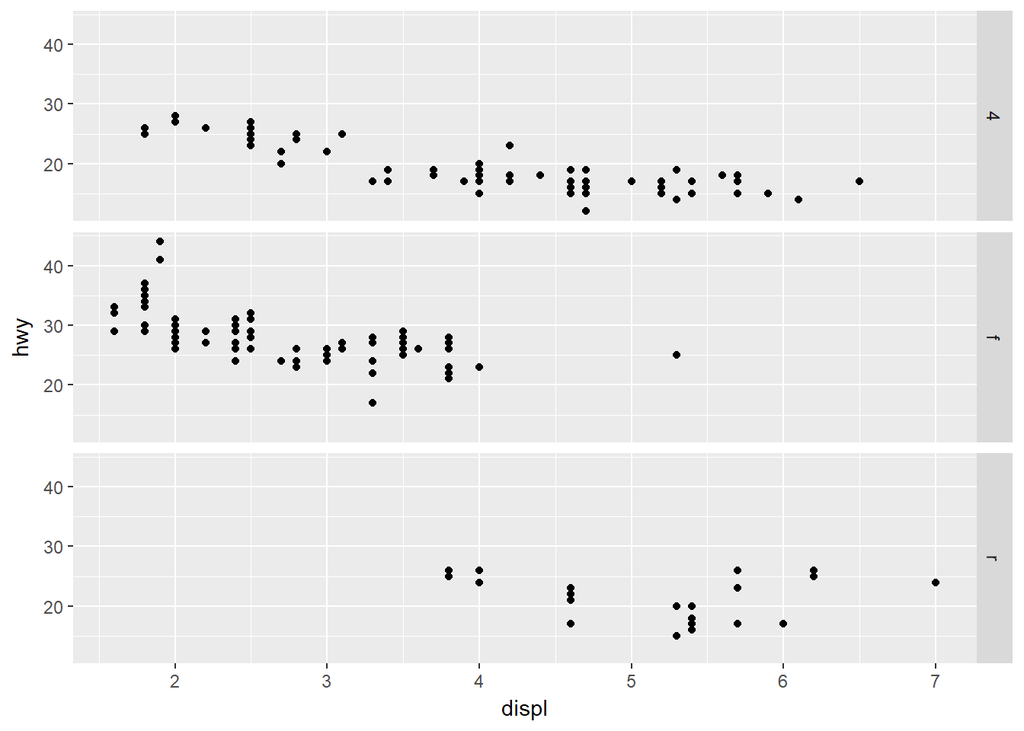

```r
ggplot(data = mpg) +
  geom_point(mapping = aes(x = displ, y = hwy)) +
  facet_grid(drv ~ .)
```

The “.” will mean there is only one dimension, we don´t have colummun dimension within the facet

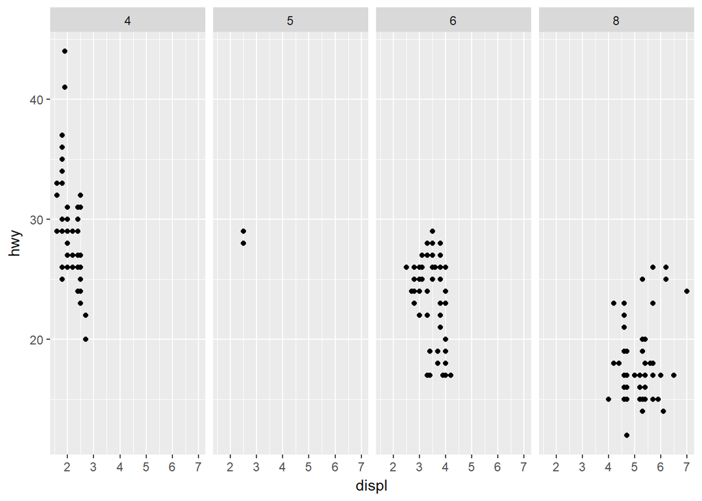

```r
ggplot(data = mpg) +
  geom_point(mapping = aes(x = displ, y = hwy)) +
  facet_grid(. ~ cyl)
```

Alternatively, in this case we don´t have the row dimension